# Tutorial #2 - Selection on Observables and DAGs

Treatment Effects - The Basics

Francis J. DiTraglia

University of Oxford

# Part I: Selection on Observables

## Electoral Effects of Biased Media

- Based on: [Peisakhin & Rozenas (2018) - Electoral Effects of Biased Media: Russian Television in Ukraine](https://www.almendron.com/tribuna/wp-content/uploads/2018/04/electoral-effects-of-biased-media-russian-television-in-ukraine.pdf)
- In the lead-up to Ukraine’s 2014 parliamentary election, Russian state-controlled TV mounted a fierce media campaign against the Ukrainian government.
- Ukrainians who lived near the border with Russia could receive Russian TV signals.
- Causal effect of Russian media on Ukrainian election?
- **Observational** rather than experimental data.

## 💪 Load the Data

The dataset we’ll use in this tutorial is `UA_precincts.csv`, available from the `data` directory of my website: https://ditraglia.com.

### `precincts`

```r
library(tidyverse)
precincts <- read_csv('https://ditraglia.com/data/UA_precincts.csv')
precincts
```

```
# A tibble: 3,589 × 4
   russian_tv pro_russian prior_pro_russian within_25km
        <dbl>       <dbl>             <dbl>       <dbl>
 1          0       2.72               25.1           1
 2          0       0.893              35.3           0
 3          1       1.69               20.5           1
 4          0      72.3                84.5           1
 5          0       1.28               29.0           0
 6          1       1.43               45.6           0
 7          0       1.57               36.1           0
 8          0       1.64               31.2           0
 9          0       1.73               25.9           0
10          0       1.79               27.2           0
# ℹ 3,579 more rows
```

Aggregate election results in precincts close to the Russian border.

### `precincts`

- Each row is a *precinct* near the Russian border.
- `russian_tv` equals `1` if precinct has Russian TV reception.
- `pro_russian` precinct’s vote share (percentage) of pro-Russian parties in 2014 Ukrainian election.
- `prior_pro_russian` same for 2012 election.
- `within_25km` equals `1` if precinct is within 25km of border.

Our treatment variable is `russian_tv`; our outcome variable is the *change* in pro-Russian vote share between 2012 and 2014.

## 💪 Exercise

1. Construct a new variable `change` that equals the change in pro-Russian vote share between 2012 and 2014 and append it to `precinct`.
2. How does the change in vote shares differ between precincts with and without Russian TV reception?
3. Do precincts with and without Russian TV reception differ in any other ways that we can discern from the dataset?

## Solution

```r
precincts <- precincts |>
  mutate(change = pro_russian - prior_pro_russian) |>
  select(-pro_russian, -prior_pro_russian)

precincts |>
  group_by(russian_tv) |>
  summarize(avg_change = mean(change),
            share_within_25k = mean(within_25km))
```

```
# A tibble: 2 × 3
  russian_tv avg_change share_within_25k
       <dbl>      <dbl>            <dbl>
1          0      -25.1           0.0577
2          1      -23.4           0.539
```

### A Slicker Way

```r
library(modelsummary)
datasummary_balance(~ russian_tv, precincts)
```

|  | 0 Mean | 0 Std. Dev. | 1 Mean | 1 Std. Dev. | Diff. in Means | Std. Error |
| --- | --- | --- | --- | --- | --- | --- |
| within_25km | 0.1 | 0.2 | 0.5 | 0.5 | 0.5 | 0.0 |
| change | -25.1 | 11.1 | -23.4 | 14.3 | 1.8 | 0.6 |

## Let’s run some regressions

No adjustment for covariates:

```r
library(broom)
reg1 <- lm(change ~ russian_tv, precincts)
tidy(reg1)
```

```
# A tibble: 2 × 5
  term        estimate std.error statistic  p.value
  <chr>          <dbl>     <dbl>     <dbl>    <dbl>
1 (Intercept)   -25.1      0.220   -114.   0
2 russian_tv      1.78     0.499      3.57 0.000355
```

Try adjusting for distance:

```r
reg2 <- lm(change ~ russian_tv + within_25km, precincts)
tidy(reg2)
```

```
# A tibble: 3 × 5
  term        estimate std.error statistic   p.value
  <chr>          <dbl>     <dbl>     <dbl>     <dbl>
1 (Intercept)   -24.3      0.207    -118.  0
2 russian_tv      8.82     0.546      16.2 8.96e- 57
3 within_25km   -14.6      0.603     -24.3 1.93e-120
```

## A Prettier Way to Display The Results

```r
results <- list(reg1, reg2)
modelsummary(results, gof_omit = 'Log.Lik|R2 Adj.|AIC|BIC|F', fmt = 2)
```

|  | (1) | (2) |
| --- | --- | --- |
| (Intercept) | −25.15 | −24.30 |
|  | (0.22) | (0.21) |
| russian_tv | 1.78 | 8.82 |
|  | (0.50) | (0.55) |
| within_25km |  | −14.61 |
|  |  | (0.60) |
| Num.Obs. | 3589 | 3589 |
| R2 | 0.004 | 0.144 |
| RMSE | 11.81 | 10.95 |

## 💪 Exercise

1. Use the regression adjustment idea from our lecture to control for `within_25km` “the hard way” i.e. without running a regression.
2. Compare your results to those from above. Can you explain the discrepancy?

```r
means <- precincts |>
  group_by(within_25km, russian_tv) |>
  summarize(avg_change = mean(change))
means
```

```
# A tibble: 4 × 3
# Groups:   within_25km [2]
  within_25km russian_tv avg_change
        <dbl>      <dbl>      <dbl>
1           0          0      -24.6
2           0          1      -13.0
3           1          0      -34.2
4           1          1      -32.2
```

```r
means <- means |>
  pivot_wider(names_from = russian_tv,
              values_from = avg_change,
              names_prefix = 'ybar')
means
```

```
# A tibble: 2 × 3
# Groups:   within_25km [2]
  within_25km ybar0 ybar1
        <dbl> <dbl> <dbl>
1           0 -24.6 -13.0
2           1 -34.2 -32.2
```

```r
regression_adjustment <- precincts |>
  group_by(within_25km) |>
  summarize(count = n()) |>
  mutate(prop = count / sum(count)) |>
  select(-count) |>
  left_join(means)

regression_adjustment
```

```
# A tibble: 2 × 4
  within_25km  prop ybar0 ybar1
        <dbl> <dbl> <dbl> <dbl>
1           0 0.849 -24.6 -13.0
2           1 0.151 -34.2 -32.2
```

```r
regression_adjustment <- regression_adjustment |>
  mutate(out = (ybar1 - ybar0) * prop) |>
  pull(out) |>
  sum()

regression_adjustment
```

```
[1] 10.12062
```

Disagrees with coefficient on `russian_tv` from `reg2`

```r
coef(reg2)
```

```
(Intercept)  russian_tv within_25km
 -24.302164    8.822285  -14.613914
```

```r
precincts <- precincts |>
  mutate(x = within_25km - mean(within_25km))
reg3 <- lm(change ~ russian_tv * x, precincts)
tidy(reg3)
```

```
# A tibble: 4 × 5
  term         estimate std.error statistic  p.value
  <chr>           <dbl>     <dbl>     <dbl>    <dbl>
1 (Intercept)    -26.0      0.218   -120.   0
2 russian_tv      10.1      0.565     17.9  8.47e-69
3 x               -9.60     0.866    -11.1  3.85e-28
4 russian_tv:x    -9.56     1.20      -7.99 1.75e-15
```

Coefficient on `russian_tv` agrees with hand calculation:

```r
regression_adjustment
```

```
[1] 10.12062
```

# Part II - DAGs

## Building your DAG

```r
library(ggdag)
myDAG <- dagify(Y ~ X + D + Z,
                X ~ Z,
                D ~ X)

myDAG
```

```
dag {
D
X
Y
Z
D -> Y
X -> D
X -> Y
Z -> X
Z -> Y
}
```

## Plotting your DAG

```r
myDAG |> ggdag()
```

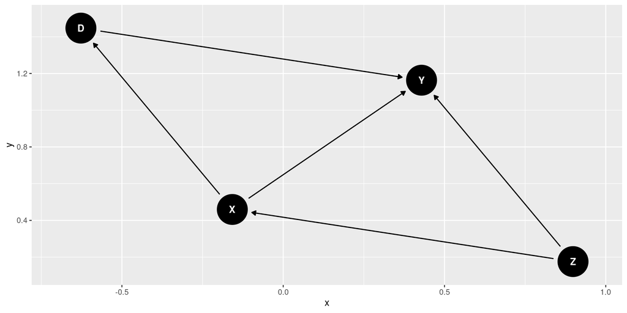

## Improve DAG Formatting

```r
myDAG |> ggdag(node_size = 15, text_size = 8) + # adjust size
  theme_dag()  # remove axes etc.
```

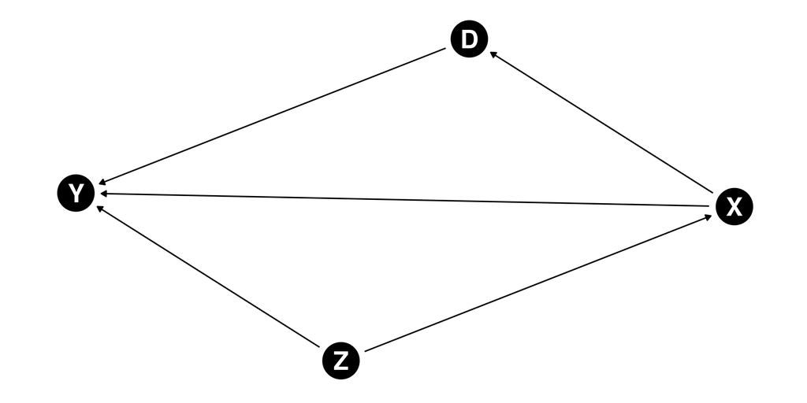

## Adjust the DAG Layout

```r
myDAG <- dagify(Y ~ X + D + Z,
                X ~ Z,
                D ~ X,
  # Specify Cartesian coordinates of each node
  coords = list(x = c(Z = 2, X = 1, D = 1, Y = 2),
                y = c(Z = 2, X = 2, D = 1, Y = 1))
)

# Plot appears on next slide
myDAG |>
  ggdag(node_size = 15, text_size = 8) +
  theme_dag()
```

## Adjust the DAG Layout

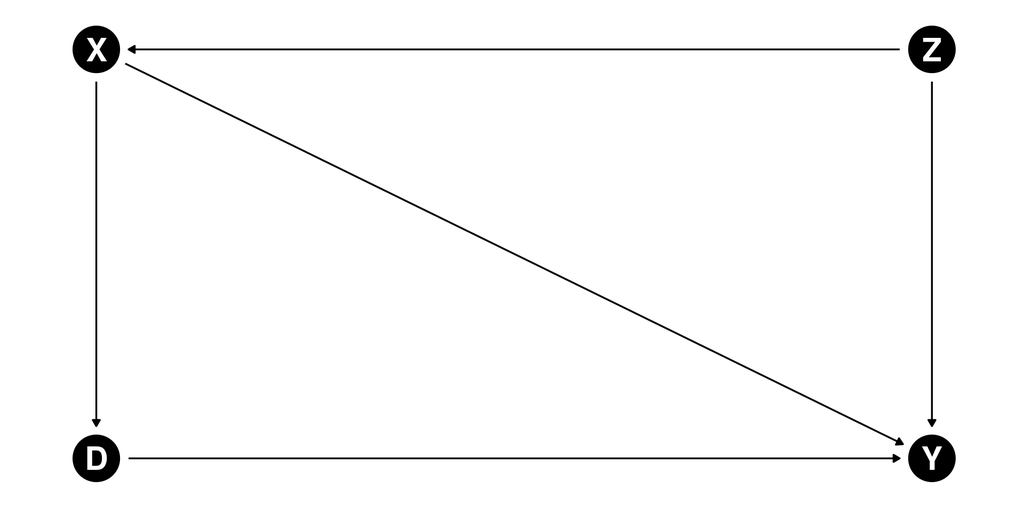

## Listing Paths

```r
library(dagitty)

# All paths between D and Y
paths(myDAG, from = 'D', to = 'Y')
```

```
$paths
[1] "D -> Y"           "D <- X -> Y"      "D <- X <- Z -> Y"

$open
[1] TRUE TRUE TRUE
```

```r
# Only directed (i.e. causal) paths from D to Y
paths(myDAG, from = 'D', to = 'Y', directed = TRUE)
```

```
$paths
[1] "D -> Y"

$open
[1] TRUE
```

## Finding Adjustment Sets

```r
# What to adjust for to learn the D -> Y effect?
myDAG |>
   adjustmentSets(exposure = 'D', outcome = 'Y')
```

```
{ X }
```

```r
# The X -> Y effect?
myDAG |>
   adjustmentSets(exposure = 'X', outcome = 'Y')
```

```
{ Z }
```

```r
# The Z -> effect?
myDAG |>
   adjustmentSets(exposure = 'Z', outcome = 'Y')
```

```
 {}
```

## Effect of Exercise on Cancer

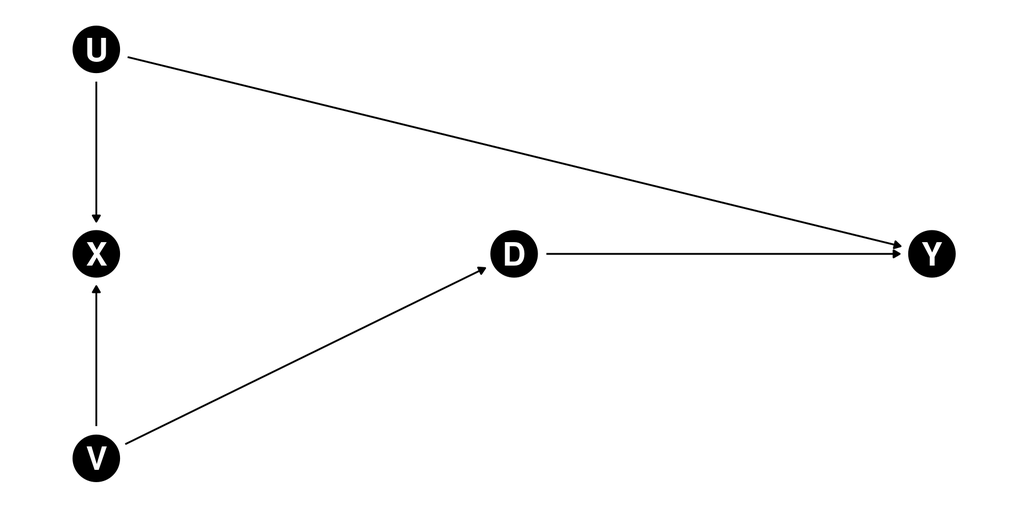

Should we adjust for $X$ in this DAG to learn the $D \rightarrow Y$ effect?

### Observed

- $D=$ physical activity
- $Y=$ cervical cancer (Yes/No)
- $X=$ positive pap smear test result (Yes/No)

### Unobserved

- $U=$ pre-cancer lesion (Yes/No)
- $V=$ health-consciousness

### Story

Health-conscious $\Rightarrow$ more physically active and more visits to doctor. Does this mean we should adjust for $X$?

## 💪 Exercise

1. Plot the exercise / cancer DAG from two slides back.
2. Use `daggity` to list all paths between $D$ and $Y$.
3. Use `daggity` to find the adjustment sets for $D \rightarrow Y$.
4. Should we adjust for $X$? Why or why not?

```r
exerciseDAG <- dagify(Y ~ D + U,
                      D ~ V,
                      X ~ U + V,
  coords = list(x = c(U = 1, X = 1, V = 1, D = 2, Y = 3),
                y = c(U = 3, X = 2, V = 1, D = 2, Y = 2))
)

exerciseDAG |>
  ggdag(node_size = 15, text_size = 8) +
  theme_dag()
```

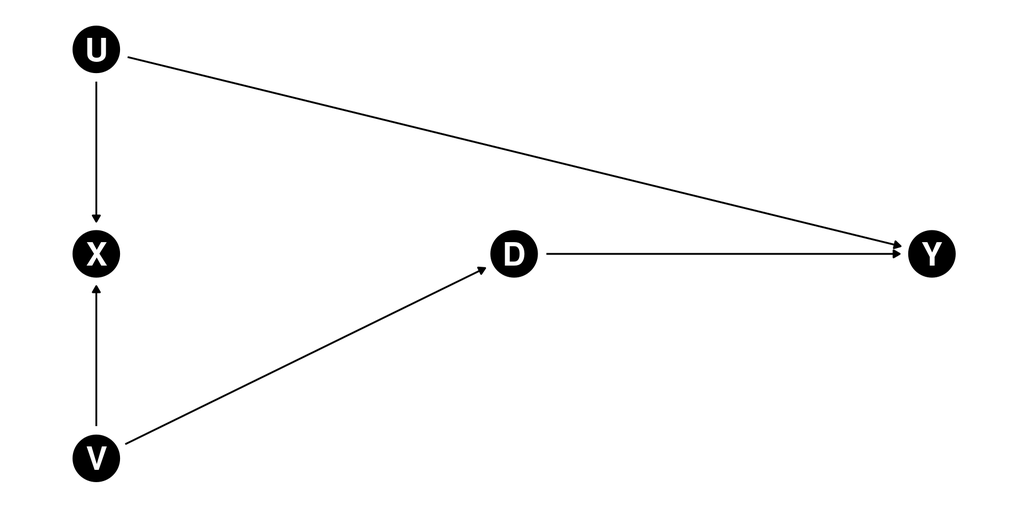

```r
exerciseDAG |>
  paths(from = 'D', to = 'Y')
```

```
$paths
[1] "D -> Y"                "D <- V -> X <- U -> Y"

$open
[1]  TRUE FALSE
```

```r
exerciseDAG |>
  adjustmentSets(exposure = 'D', outcome = 'Y')
```

```
 {}
```

- In the DAG $X$ is a *collider*.
- Blocks the backdoor path from $D$ to $Y$ through $V$.
- Conditioning on it *opens* the path.